# InVivoStat Graphics

## Selected variables

The variable Resp 1 has been selected as the response and the variable Time 1 has been selected to define the X-axis. The variables Cat1 and Cat2 have been selected as the categorisation factors. The variable Animal2 defines the case profiles.

## Categorised case profiles plot

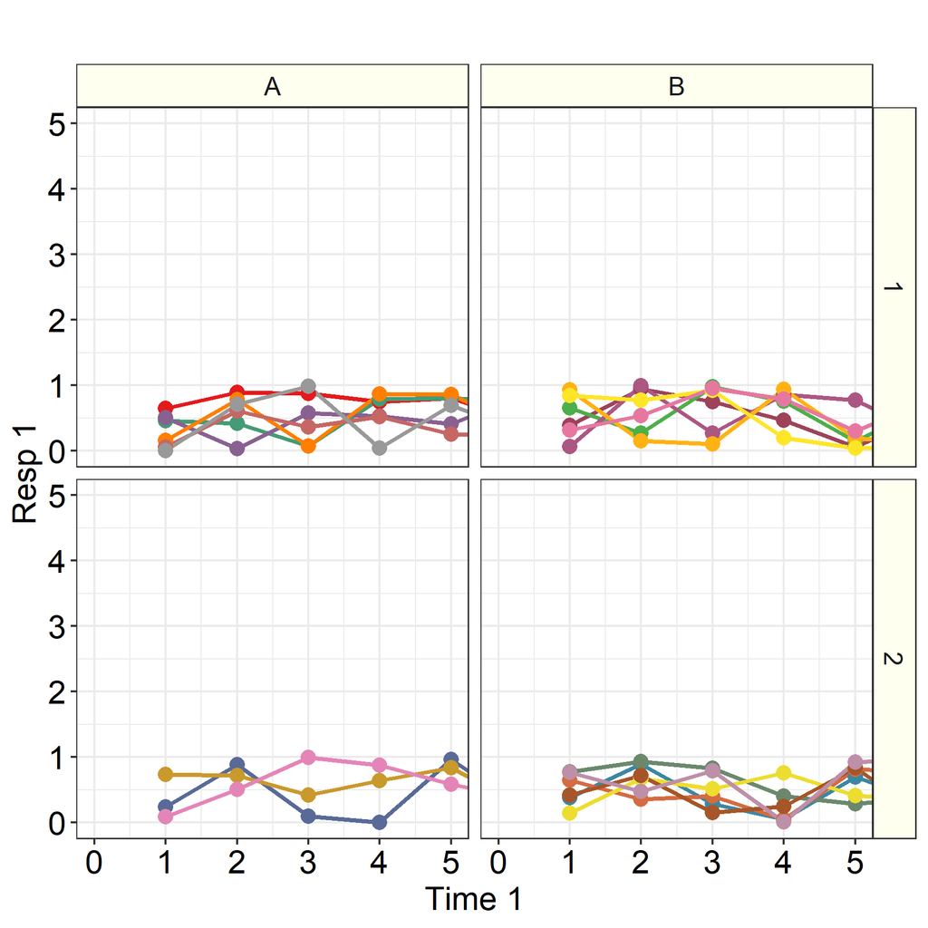

For more information on the theoretical approaches that are implemented within this module, see Bate and Clark (2014).

## References

When referring to InVivoStat, please cite 'InVivoStat, version 4.4'.

Bate, S.T. and Clark, R.A. (2014). The Design and Statistical Analysis of Animal Experiments. Cambridge University Press.

#### R references

R Development Core Team (2013). R: A language and environment for statistical computing. R Foundation for Statistical Computing, Vienna, Austria. URL http://www.R-project.org.

Lecoutre, Eric (2003). The R2HTML Package. R News, Vol 3. N. 3, Vienna, Austria.

Barret Schloerke, Di Cook, Joseph Larmarange, Francois Briatte, Moritz Marbach, Edwin Thoen, Amos Elberg and Jason Crowley (2021). GGally: Extension to 'ggplot2'. R package version 2.1.2. https://CRAN.R-project.org/package=GGally

Erich Neuwirth (2022). RColorBrewer: ColorBrewer Palettes. R package version 1.1-3. https://CRAN.R-project.org/package=RColorBrewer

H. Wickham. ggplot2: Elegant Graphics for Data Analysis. Springer-Verlag New York, 2016.

Kamil Slowikowski (2021). ggrepel: Automatically Position Non-Overlapping Text Labels with 'ggplot2'. R package version 0.9.1. https://CRAN.R-project.org/package=ggrepel

H. Wickham. Reshaping data with the reshape package. Journal of Statistical Software, 21(12), 2007.

Hadley Wickham (2011). The Split-Apply-Combine Strategy for Data Analysis. Journal of Statistical Software, 40(1), 1-29. URL https://www.jstatsoft.org/v40/i01/.

Hadley Wickham and Dana Seidel (2022). scales: Scale Functions for Visualization. R package version 1.2.0. https://CRAN.R-project.org/package=scales

Gabor Grothendieck, Louis Kates and Thomas Petzoldt (2016). proto: Prototype Object-Based Programming. R package version 1.0.0. https://CRAN.R-project.org/package=proto

## Analysis dataset

| Observation | Resp 1 | Time 1 | Cat1 | Cat2 | Animal2 |
| --- | --- | --- | --- | --- | --- |
| 1 | 0.644 | 1 | 1 | A | A1 |
| 2 | 0.894 | 2 | 1 | A | A1 |
| 3 | 0.872 | 3 | 1 | A | A1 |
| 4 | 0.746 | 4 | 1 | A | A1 |
| 5 | 0.805 | 5 | 1 | A | A1 |
| 6 | 0.439 | 6 | 1 | A | A1 |
| 7 | 0.388 | 1 | 1 | B | A10 |
| 8 | 0.945 | 2 | 1 | B | A10 |
| 9 | 0.748 | 3 | 1 | B | A10 |
| 10 | 0.465 | 4 | 1 | B | A10 |
| 11 | 0.056 | 5 | 1 | B | A10 |
| 12 | 0.563 | 6 | 1 | B | A10 |
| 13 | 0.239 | 1 | 2 | A | A11 |
| 14 | 0.883 | 2 | 2 | A | A11 |
| 15 | 0.096 | 3 | 2 | A | A11 |
| 16 | 0.002 | 4 | 2 | A | A11 |
| 17 | 0.960 | 5 | 2 | A | A11 |
| 18 | 0.227 | 6 | 2 | A | A11 |
| 19 | 0.380 | 1 | 2 | B | A12 |
| 20 | 0.887 | 2 | 2 | B | A12 |
| 21 | 0.281 | 3 | 2 | B | A12 |
| 22 | 0.051 | 4 | 2 | B | A12 |
| 23 | 0.690 | 5 | 2 | B | A12 |
| 24 | 0.319 | 6 | 2 | B | A12 |
| 25 | 0.459 | 1 | 1 | A | A13 |
| 26 | 0.418 | 2 | 1 | A | A13 |
| 27 | 0.074 | 3 | 1 | A | A13 |
| 28 | 0.786 | 4 | 1 | A | A13 |
| 29 | 0.801 | 5 | 1 | A | A13 |
| 30 | 0.746 | 6 | 1 | A | A13 |

[output cut: 96 more lines]

## Analysis options

Response variable: Resp 1

X-axis variable: Time 1

First categorisation factor: Cat1

Second categorisation factor: Cat2

Categorised gragh style: separate

Display legend (Y/N): Y

X-axis title (except for Histogram): Time 1

Y-axis title: Resp 1

Output Case profiles plot (Y/N): Y

Case ID factor: Animal2

Shown case ID's in legend: N